# Compensation and Benefits

PUBADM 505

2026-10-12

## Outline

- BSU Case Study: HR now reports to the president
- What are we paying for?
- Benefits
- Pay law and pay now
- After the break: Paying the Tucson Police

## Boise State: HR Now Reports to the President

## On the Horizon with President Hahn

“I am excited to share with you that I am shifting our reporting structure so that **Human Resources now reports directly to my office.** From recruitment and compensation to employee relations and policy development, the work of the HR team is important to every corner of the university. This move aligns our organizational chart with the importance of HR’s voice and support as we set institutional goals for the future.”

What changed, and why would a new president do this?

President David Hahn, “On the Horizon with President Hahn,” email to Boise State faculty and staff, Oct. 6, 2026 (emphasis added).

## Before: Boise State, September 2026

Athletics

Morrison Center

PresidentDavid Hahn

General Counsel

Title IX Compliance

President’s Professor

Academic AffairsZeynep Hansen (Interim)

FinanceStacy Pearson (Interim)

- Budget and Planning
- University Financial Services

Operations and Enterprise ServicesAnnie Hightower

- Campus Operations
- Chemical and Lab Safety
- Children’s Center
- Enterprise Project Management
- Human Resources
- Public Safety
- Office of Information Technology
- Next Frontier Program
- Art Collection
- Risk Management

Public and External AffairsMitch Zak

Research and Economic DevelopmentNancy Glenn

Student Affairs and Enrollment ManagementVacant

Boise State Office of the President, organizational chart dated Sept. 2, 2026 (simplified: division sub-units shown for Finance and Operations only; Foundation omitted).

## After: HR Reports to the President

Athletics

Morrison Center

Human Resources

PresidentDavid Hahn

General Counsel

Title IX Compliance

President’s Professor

Academic AffairsZeynep Hansen (Interim)

FinanceStacy Pearson (Interim)

- Budget and Planning
- University Financial Services

Operations and Enterprise ServicesAnnie Hightower

Public and External AffairsMitch Zak

Research and Economic DevelopmentNancy Glenn

Student Affairs and Enrollment ManagementVacant

## Possible Rationales

A seat at the table

- Week 4: transactional vs. transformational HR
- Is HR asked before a commitment is made, or after?
- From the email: “HR’s voice and support”

Closer to the top

- Week 7: presidential control of federal hiring
- Hiring, pay, and employee relations sit closer to one office
- What makes this different from the federal case?

When HR reports to the top, what changes for leadership, and what changes for employees?

## Who Owns Pay?

HR asks

- Is pay fair across similar jobs? (internal equity)
- Can we hire and keep people? (the market)

Finance asks

- Can we afford it this year?
- Can we afford it every year after?

Compensation is where HR and the budget meet.

## What Are We Paying For?

## Plan of Discussion

1

What are we paying for? Understanding a philosophy of pay

2

Understanding rationales behind different pay systems

3

Benefits: mandated and discretionary

Emphasis on strategic HRM

## A Philosophy of Pay

What do we pay for in organizations?

Employer’s perspective

- What are we buying: time, output, skills, loyalty?

Employee’s perspective

- What am I being paid for, and is it fair?

Pay is as much about symbols as it is about cash.

## Logic Model for Connecting Pay to Mission

Mission

Workforce Planning

Position Analysis

Job Description

Job Evaluation

Classification

Pay

Week 4

Strategic HRM: mission and workforce planning

Week 6

Job analysis, job descriptions, job evaluation, classification

Tonight

Pay comes last: it rests on every step above it

## Compensation Strategies

Single rate

Everyone in the job is paid the same; across-the-board cost-of-living raises tied to the Consumer Price Index

Time based

Steps based on longevity; “make no distinction between high performers and low performers”

Productivity based

Pay tied to a preset output goal; works only when outputs are “unambiguous and easily measured”

Person based

Pay follows the person’s competencies, experience, education, and seniority, not the position

Pay-for-performance

Increases “dependent on performance appraisal ratings, rather than on years of experience”

Equity adjustments

When an audit shows a job is paid below market, or similar jobs are paid very differently

Which of these have you been paid under?

## Activity: Employee or Manager?

Single rate, time based, productivity based, person based, pay-for-performance.

1. As an employee, which do you prefer and why?
2. As a manager, which do you prefer and why?
3. Does your answer change when you switch roles? Why?

10 minutes in groups

## Step Pay and Pay-for-Performance

Step-based pay

Easy to operationalize, “increments are predictable and transparent, and they do not encourage competition among coworkers.”

But “for those whose performance is motivated by raises, the reliability of increments removes the incentive to perform at a higher-than-average level.”

Pay-for-performance

“While the theory is that pay-for-performance places the decision of how hard to work on the employee, in fact, in most jobs it hands more discretion to the supervisor, who has leverage over the employee.”

Effective pay-for-performance depends on fair and effective performance appraisals. (Week 9)

Guy & Sowa instructor manual, Ch. 7 key words.

## What Motivates Public Employees?

## How Do You Motivate Public Employees?

Job securityPublic servicePay and benefitsProfessional accomplishmentDevotion to a cause, policy, or mission

Extrinsic motivation

Based on an expectation of earning some kind of external reward, or avoiding some kind of punishment

Intrinsic motivation

Based on internal satisfaction, enjoyment, and pride

Which of these brought you to your job? Which keeps you there?

## Taylor and Scientific Management (1911)

“One of the very first requirements for a man who is fit to handle pig iron as a regular occupation is that he shall be so stupid and so phlegmatic that he more nearly resembles in his mental make-up the ox than any other type.”

12½ → 47½

Tons of pig iron loaded per man per day, Bethlehem Steel

$1.15 → $1.85

“Schmidt’s” daily wage for doing it Taylor’s way

Taylor believed workers were motivated primarily by pay: pay them according to productivity.

Frederick W. Taylor, *The Principles of Scientific Management* (1911). The pursuit of “the one best way”; efficiency and economy.

## The Human Relations Movement

1911Taylor

Scientific management: the one best way; pay for output

1918Mary Parker Follett

The “law of the situation”; authority as power with, not over

1924–32Mayo: Hawthorne studies

Attention and informal groups raise productivity: money is not everything

1938Chester Barnard

The organization as a cooperative system; the “zone of indifference”

1943Abraham Maslow

A hierarchy of needs explains why people respond to different incentives

1960Douglas McGregor

Theory X and Theory Y: what managers assume about workers

The Hawthorne studies were the first empirical challenge to Taylor’s scientific management.

## Maslow’s Hierarchy of Needs (1943)

NeedWorkplace incentive

Self-actualization

Personal and professional development

Esteem

The ability to take pride in work

Social

Recognition of good performance

Security

Job security

Physiological

Salary and benefits

Where on the pyramid does tonight’s chapter live?

## McGregor: Theory X and Theory Y (1960)

Theory X

- The average person dislikes work and will avoid it if they can
- Most people must be coerced, controlled, directed, or threatened with punishment
- The average person prefers to be directed and wants security above all

Theory Y

- Effort at work is as natural as play or rest
- Control and threats are not the only ways to bring about effort
- Commitment to objectives is a function of the rewards for achieving them
- Under the right conditions, people seek responsibility

Which theory does step pay assume? Which does pay-for-performance assume?

## Video: Ron’s Method vs. Chris’s Method

“Ron’s method vs Chris’ method,” *Parks and Recreation*, Season 5, “Article Two” (3:54, [open on YouTube](https://www.youtube.com/watch?v=iegCuhhXwi0))

[interactive chart not shown]

Which method relies on intrinsic motivation, and which on extrinsic? Where would pay fit in each?

## Chris’s Method or Ron’s Method?

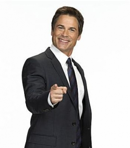

Chris Traeger

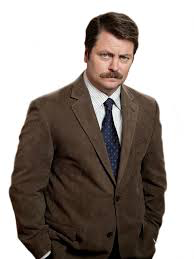

Ron Swanson

Theory X or Theory Y? Which of Maslow’s needs does each one speak to? Who would you rather work for?

## Public Service Motivation

“An individual’s predisposition to respond to motives grounded primarily or uniquely in public institutions and organizations.”

Rational

Participating in policymaking; a need for power and recognition

Norm-based

A sense of duty: public service is the right thing to do

Affective

Public service feels good: satisfaction from helping the community

Week 7 callback: in Chattanooga, the “ready to serve?” postcard brought in no more applicants than no postcard at all.

Perry, J. L., & Wise, L. R. (1990). The motivational bases of public service. *Public Administration Review*, 50(3), 367–373 (definition, p. 368).

## Pay-for-Performance and Intrinsic Motivation

Weibel, Rost, and Osterloh (2010)

A meta-analysis of experiments plus a vignette study: pay for performance raises effort through extrinsic motivation, but it can crowd out intrinsic motivation. It “is generally more costly as it appears because it almost always produces hidden costs of rewards.”

For public managers

- Structure work and incentives to account for public service motivation
- Be careful applying private sector pay practices to the public sector

If public employees are motivated by service, what should government pay for?

Weibel, A., Rost, K., & Osterloh, M. (2010). Pay for performance in the public sector—Benefits and (hidden) costs. *JPART*, 20(2), 387–412.

## Evaluating Jobs for Compensation

Compensable factors: the elements of a job that give it value

Level and breadth of responsibilityKnowledge requirementsTask complexityIndependent judgmentError impactConfidentialitySupervisory responsibilityEducational requirements

Point factor method

Score each factor

→

Factors to points

Add up the job’s points

→

Points to grades

Point ranges map to grades

→

Grade to salary range

Each grade has a minimum and maximum

Usually six to twelve factors. The General Schedule’s Factor Evaluation System (Week 6) is one version.

## Classification Systems

Rank-in-position

- Salary, benefits, and rank are tied to the position
- Move jobs, and you must qualify for the new grade
- Example: the General Schedule

Rank-in-person

- Salary, benefits, and rank travel with the person
- Pay reflects competencies, experience, education, performance, seniority
- Examples: the U.S. military, the Foreign Service

Alternatives within classification: paybanding and broadbanding, which give managers discretion over pay within a wide band (China Lake, Week 6).

Your experiences? Which system are you in now?

## Benefits

## Benefits

1

Useful for recruiting and retaining staff

2

Which benefits are most meaningful to employees?

3

Tangible and intangible benefits

4

The difference between mandated and discretionary benefits

What benefits do you look for when considering a job? What matters more now than early in your career?

## Mandated and Discretionary Benefits

Mandated

- Family and medical leave
- Social Security
- Medicare
- Workers’ compensation
- Unemployment insurance

Common discretionary

- Health, dental, and vision insurance
- Paid leave
- Award programs
- Employee assistance programs
- Retirement
- Work/life benefits

How do these differ between nonprofits and government?

## Defined Benefit vs. Defined Contribution

Defined benefit

The benefit is “based on a predetermined formula and the employer’s fund is responsible for providing the benefit for the lifetime of the retired employee.”

**The employer bears the risk.**

Defined contribution

The benefit “depends on how much they contribute to the plan over time and how financial markets perform.”

**The employee bears the risk.**

Idaho’s PERSI base plan is a defined benefit plan; many Boise State faculty and professional staff are instead in the Optional Retirement Plan (defined contribution). Federal FERS combines a basic annuity (defined benefit), the Thrift Savings Plan (defined contribution), and Social Security.

Guy & Sowa instructor manual, Ch. 7 key words.

## Pay Law and Pay Now

## Major Laws Governing Compensation

1938Fair Labor Standards Act

Minimum wage and overtime; exempt vs. nonexempt

1949Classification Act

Creates the General Schedule; equal pay for substantially equal work

1963Equal Pay Act

No sex-based wage differences for substantially equal work

1964Title VII, Civil Rights Act

No pay discrimination by race, color, religion, sex, or national origin

1993Family and Medical Leave Act

Unpaid, job-protected leave for family and medical reasons

2009Lilly Ledbetter Fair Pay Act

Each discriminatory paycheck is a separate violation

2010Affordable Care Act

Employer health coverage requirements

Guy & Sowa instructor manual, Ch. 7 key dates.

## Exempt vs. Non-exempt

Exempt

- Not covered by the FLSA’s overtime provisions
- Executive, professional, or administrative, and meets the criteria
- Generally paid a salary

Non-exempt

- Overtime for all hours beyond 40 in the work week
- Applies whether paid hourly or salaried
- Public employers may give comp time (at time and a half) instead of cash

**Where it stands in 2026.** Exempt status requires at least $684 a week ($35,568 a year). A court vacated the 2024 increase in November 2024; DOL restored the 2019 level May 15, 2026.

29 CFR 541.600 · 29 U.S.C. § 207(o) · *Texas v. U.S. Department of Labor* (E.D. Tex., Nov. 15, 2024) · DOL technical amendment, effective May 15, 2026

## True or False?

Cost-of-living raises are across-the-board pay increases that are linked to the Consumer Price Index.

True

Paid family leave is required for at least four weeks in government organizations.

False

Equity adjustments are needed when salary compression occurs in organizations.

True

## Bringing It Together

- Compensation and benefits are essential considerations for all organizations
- Compensation has tangible and intangible effects for people
- There is not one perfect compensation plan. Employers need to consider:

EquityFairnessEase of administrationAlignment with the marketSustainability

The purpose of organizations is to achieve a mission. Compensating people for contributing to this mission is an essential component of achieving high performance.

## Pay Freezes, Federal and State

0%

2027 raise for federal civilian employees: base and locality pay frozen at 2026 rates

3.8%

2027 raise for federal law enforcement, through OPM special rates

No raise

Idaho state employees, FY 2027: no Change in Employee Compensation (CEC). State base pay averages 15% behind the market median.

If pay can’t move, what can HR still offer? And why would law enforcement be the exception?

Alternative pay plan letter, Aug. 26, 2026 (final in December) · Boise State HR, CEC page · Idaho DHR, FY 2027 CEC recommendation

## Case Study: Paying the Tucson Police

## The Final Paper at a Glance

10–12

Pages, double-spaced, APA style

8+

Sources, at least four of them peer-reviewed journal articles

Dec. 16

Paper due in Canvas. Presentations Nov. 30 and Dec. 7

Introduction

Research question or thesis

→

Literature review

Debates, gaps, current knowledge

→

Analysis

Course concepts plus your research

→

Conclusion

Implications and future research

## Next Week…

**October 19: Training, developing, and retaining; performance management**

Guy & Sowa, Chapters 8 and 9

**Case:** The Gentleman’s “Three” (student-led)